# Разделение смеси распределений. Кластеризация

Ширинкина Дарья, Сальников Дмитрий, 622гр.

```r
library(rattle.data)
library(ggfortify)
library(psych)
library(cluster)
library(kohonen)
library(mclust)
library(class)
```

Данные **wine** из пакета **rattle.data**.

1. Type - The type of wine, into one of three classes, 1 (59 obs), 2(71 obs), and 3 (48 obs) (тип вина)
2. Alcohol - Alcohol (содержание алкоголя)
3. Malic - Malic acid (содержание яблочной кислоты)
4. Ash - Ash
5. Alcalinity - Alcalinity of ash (содержание щелочи)
6. Magnesium - Magnesium (содержание магния)
7. Phenols - Total phenols (общее число фенолов)
8. Flavanoids - Flavanoids (флавоноиды)
9. Nonflavanoids - Nonflavanoid phenols (не флавоноидные фенолы)
10. Proanthocyanins - Proanthocyanins (проантоцианидиныы)
11. Color - Color intensity (интенсивность цвета)
12. Hue - Hue (оттенок вина)
13. Dilution - D280/OD315 of diluted wines (разбавленность вина)
14. Proline - Proline (сорт вина)

## PCA

```r
head(wine)
```

```
##   Type Alcohol Malic  Ash Alcalinity Magnesium Phenols Flavanoids
## 1    1   14.23  1.71 2.43       15.6       127    2.80       3.06
## 2    1   13.20  1.78 2.14       11.2       100    2.65       2.76
## 3    1   13.16  2.36 2.67       18.6       101    2.80       3.24
## 4    1   14.37  1.95 2.50       16.8       113    3.85       3.49
## 5    1   13.24  2.59 2.87       21.0       118    2.80       2.69
## 6    1   14.20  1.76 2.45       15.2       112    3.27       3.39
##   Nonflavanoids Proanthocyanins Color  Hue Dilution Proline
## 1          0.28            2.29  5.64 1.04     3.92    1065
## 2          0.26            1.28  4.38 1.05     3.40    1050
## 3          0.30            2.81  5.68 1.03     3.17    1185
## 4          0.24            2.18  7.80 0.86     3.45    1480
## 5          0.39            1.82  4.32 1.04     2.93     735
## 6          0.34            1.97  6.75 1.05     2.85    1450
```

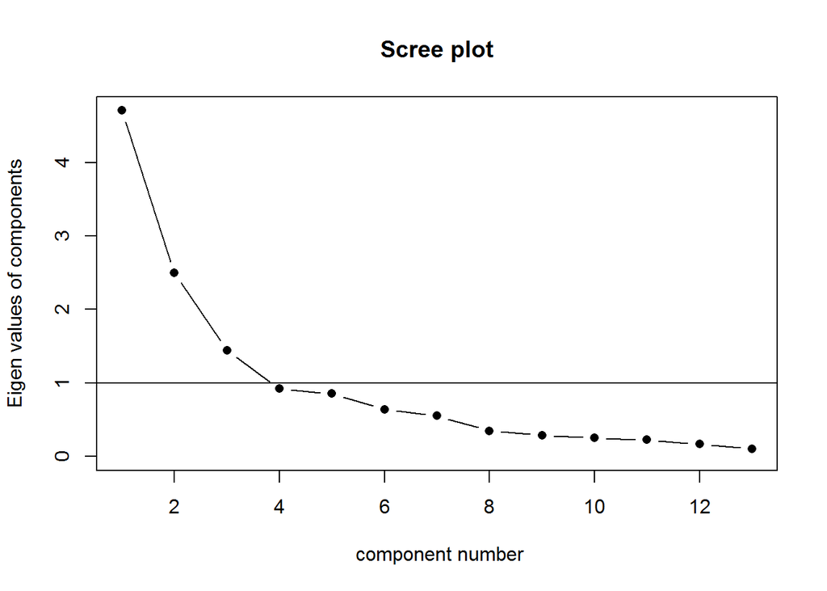

```r
wine.pca <- prcomp(x = wine[, -1], center = TRUE, scale. = TRUE)

scree(wine[, -1],factors = FALSE)
```

```r
wine.pca$rotation[, 1:4]
```

```
##                          PC1          PC2         PC3         PC4
## Alcohol         -0.144329395  0.483651548 -0.20738262  0.01785630
## Malic            0.245187580  0.224930935  0.08901289 -0.53689028
## Ash              0.002051061  0.316068814  0.62622390  0.21417556
## Alcalinity       0.239320405 -0.010590502  0.61208035 -0.06085941
## Magnesium       -0.141992042  0.299634003  0.13075693  0.35179658
## Phenols         -0.394660845  0.065039512  0.14617896 -0.19806835
## Flavanoids      -0.422934297 -0.003359812  0.15068190 -0.15229479
## Nonflavanoids    0.298533103  0.028779488  0.17036816  0.20330102
## Proanthocyanins -0.313429488  0.039301722  0.14945431 -0.39905653
## Color            0.088616705  0.529995672 -0.13730621 -0.06592568
## Hue             -0.296714564 -0.279235148  0.08522192  0.42777141
## Dilution        -0.376167411 -0.164496193  0.16600459 -0.18412074
## Proline         -0.286752227  0.364902832 -0.12674592  0.23207086
```

```r
summary(wine.pca)
```

```
## Importance of components%s:
##                          PC1    PC2    PC3     PC4     PC5     PC6     PC7
## Standard deviation     2.169 1.5802 1.2025 0.95863 0.92370 0.80103 0.74231
## Proportion of Variance 0.362 0.1921 0.1112 0.07069 0.06563 0.04936 0.04239
## Cumulative Proportion  0.362 0.5541 0.6653 0.73599 0.80162 0.85098 0.89337
##                            PC8     PC9   PC10    PC11    PC12    PC13
## Standard deviation     0.59034 0.53748 0.5009 0.47517 0.41082 0.32152
## Proportion of Variance 0.02681 0.02222 0.0193 0.01737 0.01298 0.00795
## Cumulative Proportion  0.92018 0.94240 0.9617 0.97907 0.99205 1.00000
```

Данные в двух первых компонентах.

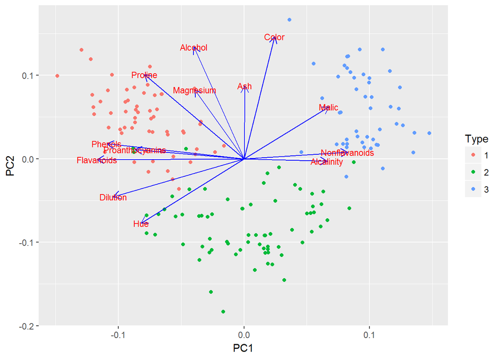

```r
autoplot(wine.pca, data = wine, colour = 'Type',
         loadings = TRUE, loadings.colour = 'blue',
         loadings.label = TRUE, loadings.label.size = 3)
```

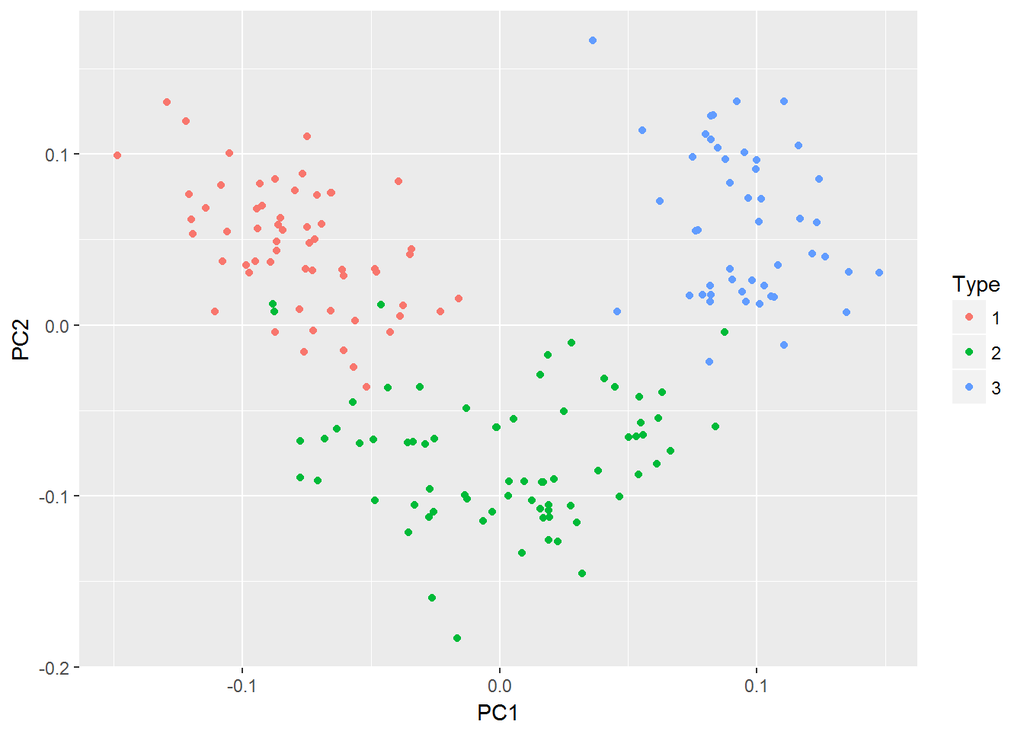

```r
autoplot(wine.pca, data = wine, colour = 'Type')
```

```r
wine.pca.data <- wine.pca$x
```

## EM-алгоритм

Применим EM-алгоритм. Будем предполагать смесь нормальных распределений.

```r
wine.mclust <- Mclust(wine.pca.data)
BIC <- mclustBIC(wine.pca.data)
```

Нет четкого максимума BIC критерия, много близких значений.

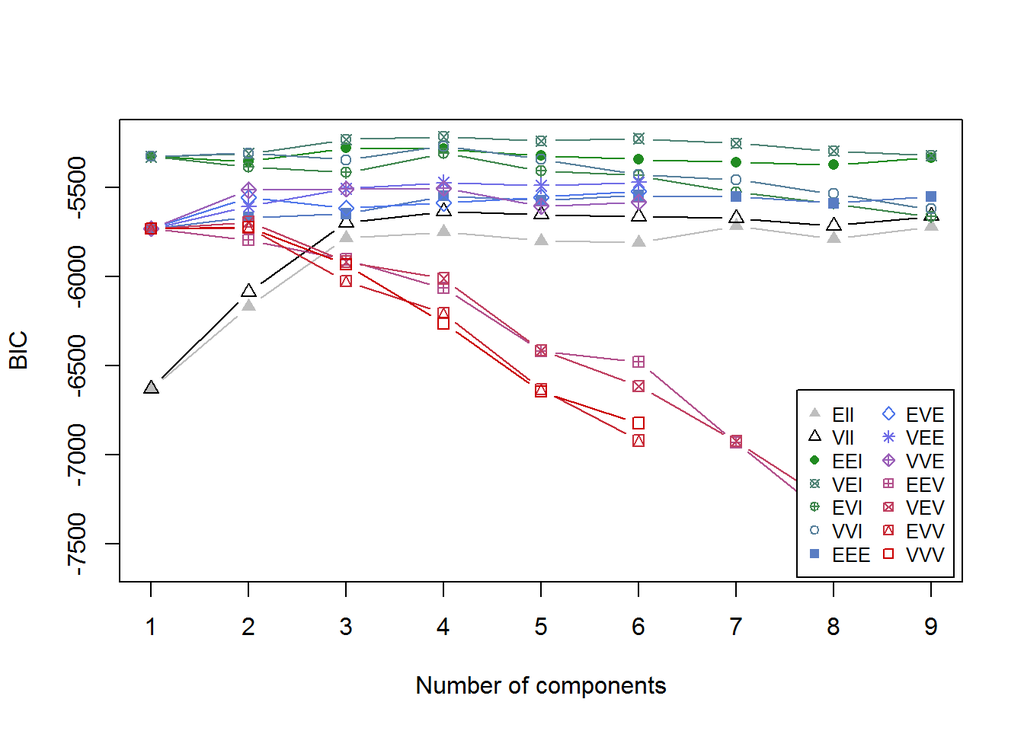

```r
plot(BIC, legendArgs = list(cex=0.8))
```

```r
summary(BIC)
```

```
## Best BIC values:
##              VEI,4        VEI,6       VEI,3
## BIC      -5213.212 -5222.410784 -5227.79894
## BIC diff     0.000    -9.199245   -14.58741
```

```r
summary(wine.mclust, parameters = FALSE)
```

```
## ----------------------------------------------------
## Gaussian finite mixture model fitted by EM algorithm
## ----------------------------------------------------
##
## Mclust VEI (diagonal, equal shape) model with 4 components:
##
##  log.likelihood   n df       BIC       ICL
##       -2422.652 178 71 -5213.212 -5231.959
##
## Clustering table:
##  1  2  3  4
## 56 31 45 46
```

Максимум BIC достигается для 4 кластеров модели VEI.

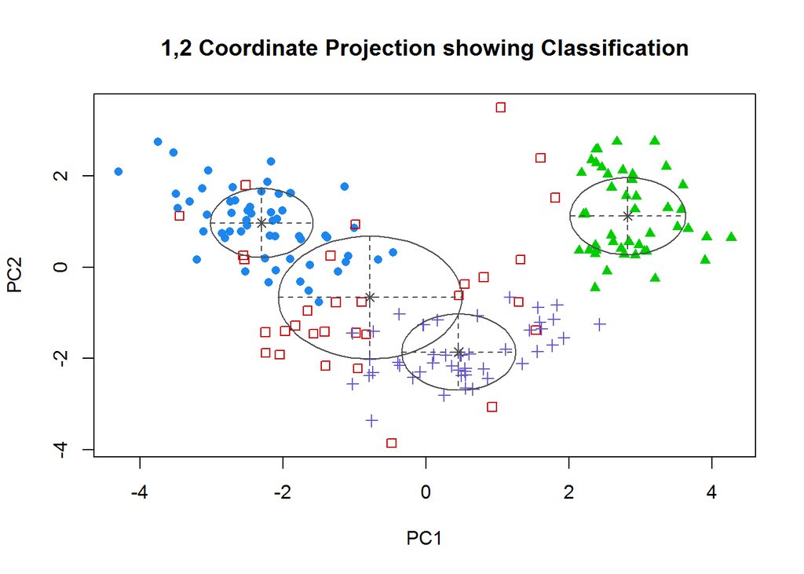

```r
plot(wine.mclust, what = "classification", dimens = 1:2)
```

Три наибольшие значения BIC имеют модель VEI для 3, 4 и 6 кластеров. Эти значения не сильно отличаются. Посмотрим на модель VEI для 3 кластеров, так как для этой модели будет меньше всего параметров.

```r
wine.mclust <- Mclust(wine.pca.data, G = 3)
summary(wine.mclust, parameters = FALSE)
```

```
## ----------------------------------------------------
## Gaussian finite mixture model fitted by EM algorithm
## ----------------------------------------------------
##
## Mclust VEI (diagonal, equal shape) model with 3 components:
##
##  log.likelihood   n df       BIC       ICL
##        -2468.81 178 56 -5227.799 -5237.348
##
## Clustering table:
##  1  2  3
## 56 74 48
```

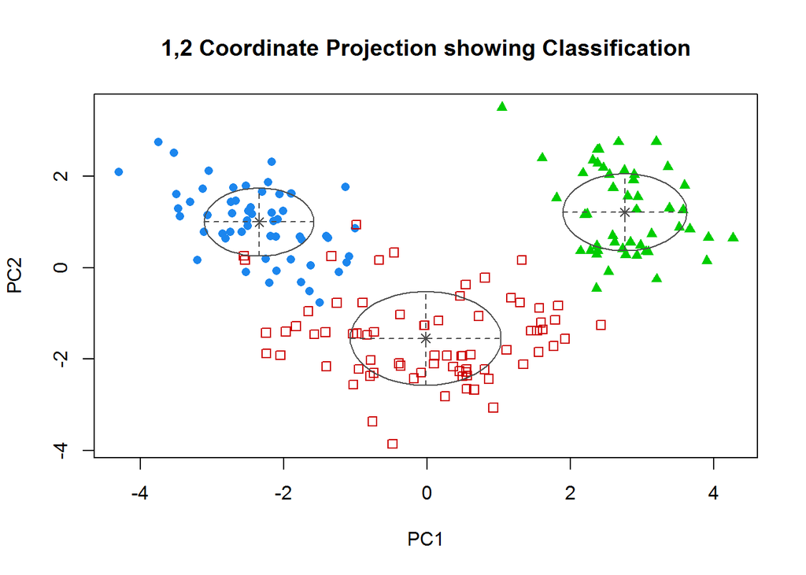

```r
plot(wine.mclust, what = "classification", dimens = 1:2)
```

Таблица правильных и ошибочных предсказаний в сравнении со значениями признака Type.

```r
tb <- table(wine$Type, wine.mclust$classification)
print(tb)
```

```
##
##      1  2  3
##   1 56  3  0
##   2  0 70  1
##   3  0  1 47
```

```r
mean(diag(prop.table(tb, 1)))
```

```
## [1] 0.9714116
```

## Алгоритм k-средних

Функция **kmeans**:

- x - данные
- centers - количество кластеров или набор центров кластеров
- iter.max - максимальное число итераций

Предположим, что наши данные делятся на две группы.

```r
set.seed(4)
wine.km.two <- kmeans(wine.pca.data, centers = 2)
```

Результат kmeans в проекции на первые два главные направления.

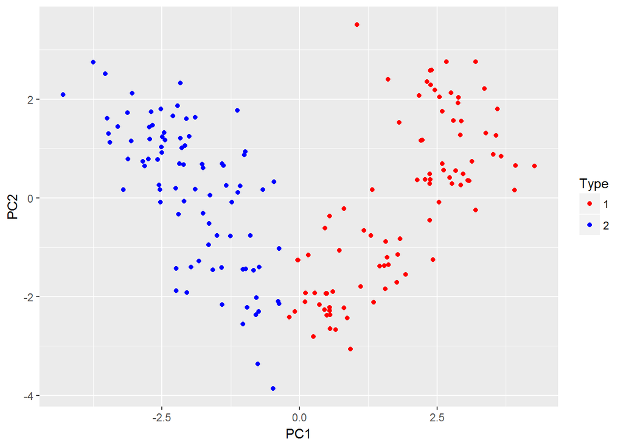

```r
ggplot(cbind(wine.pca.data, wine.km.two$cluster), aes(PC1, PC2, colour = as.factor(wine.km.two$cluster))) + geom_point() + scale_color_manual(values = c("red","blue"), name = "Type")
```

Центры признаков для двух групп, найденных kmeans.

```r
wine.km.two$centers
```

```
##         PC1        PC2         PC3         PC4         PC5         PC6
## 1  1.862923 -0.1370298 -0.01223425  0.04750315 -0.01329666 -0.04384054
## 2 -1.948575  0.1433300  0.01279675 -0.04968720  0.01390801  0.04585620
##           PC7          PC8         PC9        PC10        PC11        PC12
## 1 -0.04890362 -0.003914625 -0.02644555  0.04468521 -0.01225924 -0.02061675
## 2  0.05115207  0.004094608  0.02766144 -0.04673970  0.01282288  0.02156465
##          PC13
## 1  0.01037003
## 2 -0.01084682
```

Разделим данные на 3 группы.

```r
wine.km.three <- kmeans(wine.pca.data, centers = 3)
```

Результат kmeans в проекции на первые два главные направления.

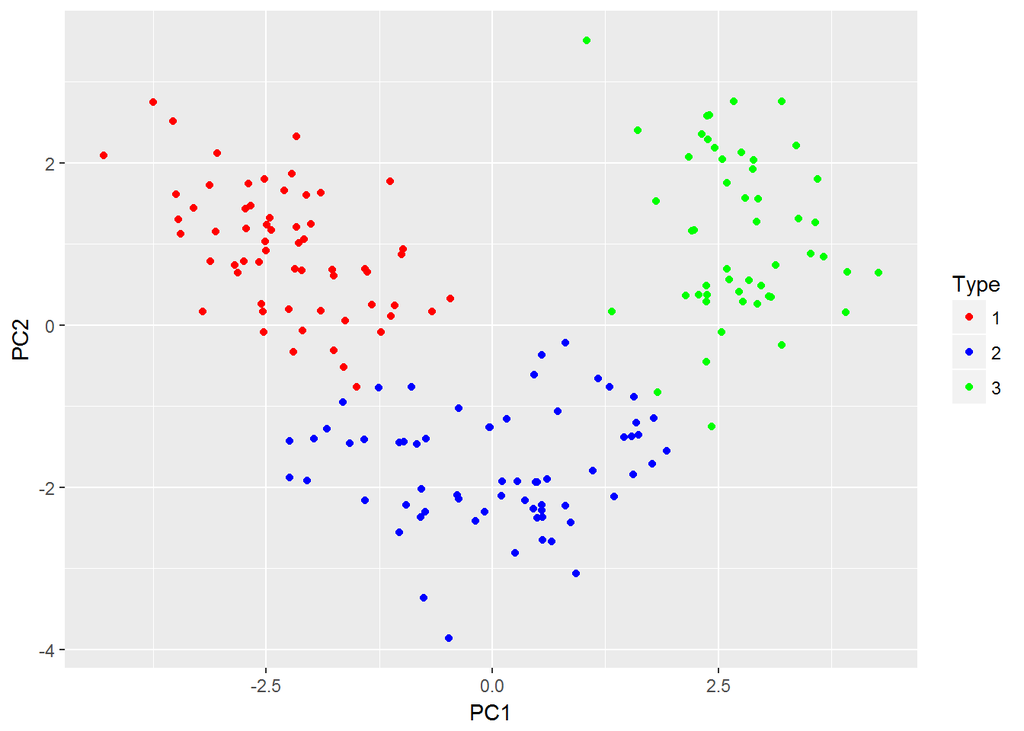

```r
ggplot(cbind(wine.pca.data, wine.km.three$cluster), aes(PC1, PC2, colour = as.factor(wine.km.three$cluster))) + geom_point() + scale_color_manual(values = c("red","blue", "green"), name = "Type")
```

Центры признаков трех типов вина.

```r
aggregate(wine.pca.data, by = list(Type = wine$Type), FUN = mean)
```

```
##   Type         PC1       PC2        PC3         PC4        PC5        PC6
## 1    1 -2.27631758  0.965151 -0.1591061  0.11201768 -0.2419097  0.2598463
## 2    2  0.03887632 -1.638860  0.2608560 -0.05082298  0.1217049 -0.1448708
## 3    3  2.74046913  1.237816 -0.1902815 -0.06251273  0.1173255 -0.1051064
##           PC7           PC8          PC9        PC10         PC11
## 1  0.02765994 -0.0242155537  0.081191635  0.07582391  0.014265363
## 2  0.04347437 -0.0008740384 -0.070471435 -0.02245465 -0.015715888
## 3 -0.09830451  0.0310578000  0.004440946 -0.05998606  0.005711909
##           PC12        PC13
## 1  0.002974867  0.03313841
## 2 -0.008190138  0.02573912
## 3  0.008457972 -0.07880508
```

Центры признаков для трех групп, найденных kmeans.

```r
wine.km.three$centers
```

```
##           PC1        PC2          PC3         PC4         PC5         PC6
## 1 -2.26979079  0.9294322  0.001523733  0.13511700 -0.13453261  0.21766922
## 2  0.03685265 -1.7672542  0.185615130 -0.08001400  0.07067870 -0.12944063
## 3  2.71238444  1.1224849 -0.238420685 -0.06228125  0.07346875 -0.09964414
##            PC7          PC8         PC9        PC10         PC11
## 1  0.051963343 -0.024894027  0.05014407  0.07446923 -0.021230820
## 2 -0.002320739  0.017964647 -0.03216049 -0.02293882  0.013900922
## 3 -0.060213318  0.007367207 -0.01997059 -0.06129547  0.008093155
##           PC12         PC13
## 1  0.007417378  0.050476861
## 2 -0.004371673 -0.008595707
## 3 -0.003445464 -0.050408713
```

Таблица правильных и ошибочных предсказаний в сравнении со значениями признака Type.

```r
tb <- table(wine$Type, wine.km.three$cluster)
print(tb)
```

```
##
##      1  2  3
##   1 59  0  0
##   2  3 65  3
##   3  0  0 48
```

```r
mean(diag(prop.table(tb, 1)))
```

```
## [1] 0.971831
```

## Нечткий алгоритм k-средних

$U = \{U_{ij}\}$ — матрица нечеткого разбиения, $U_{ij} \in [0,1]$, $i \in 1:n$, $j \in 1:k$.

В матрице $U$ $i$-ая строчка содержит степень принадлежности $(x_{i1}, \ldots ,x_{ip})$ к кластерам $C_1, \ldots , C_k$.

Критерий разброса:

$$\sum_{i \in 1:n}\sum_{j \in 1:k} U_{ij}^m\rho(X_i,\mu_j)^2,$$
где $X_i = (x_{i1}, \ldots ,x_{ip})$, $\mu_j$ — центр $j$-го кластера, а $m\in (1,\infty)$ — экспоненциальный вес, определяющий нечёткость, размытость кластеров.

На первом шаге матрица $M$ генерируется случайным образом. Далее запускается итерационный процесс вычисления центров кластеров и пересчёта элементов матрицы степеней принадлежности.

**Выбор параметра $m$.**

Чем больше значение $m$, тем матрица принадлежности более размазанная и при $m \leftarrow \infty$ элементы примут вид $\mu_{ij} = 1/k$, что является плохим решением, т.к. все объекты с одинаковой степенью распределены по всем кластерам. Теоретически обоснованного правила выбора веса пока не существует, и обычно устанавливают $m=2$.

Используем функцию **fanny** из пакета **cluster**.

- x - данные
- k - количество кластеров
- metric - метрика
- memb.exp - параметр $m$

```r
wine.fuzzy.km.three <- fanny(wine.pca.data, k = 3, metric = "SqEuclidean", memb.exp = 2)
```

Результат нечеткого k-means в проекции на первые два главные направления.

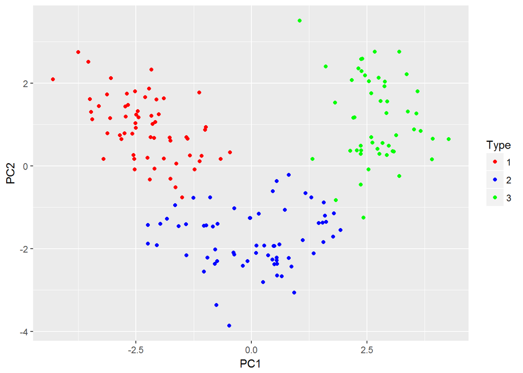

```r
ggplot(cbind(wine.pca.data, wine.fuzzy.km.three$clustering), aes(PC1, PC2, colour = as.factor(wine.fuzzy.km.three$clustering))) + geom_point() + scale_color_manual(values = c("red", "blue", "green"), name = "Type")
```

Таблица правильных и ошибочных предсказаний в сравнении со значениями признака Type. Результаты применения нечеткого k-means совпадают с результатами k-means.

```r
tb <- table(wine$Type, wine.fuzzy.km.three$clustering)
print(tb)
```

```
##
##      1  2  3
##   1 59  0  0
##   2  3 65  3
##   3  0  0 48
```

```r
mean(diag(prop.table(tb, 1)))
```

```
## [1] 0.971831
```

Элементы матрицы $U$ для трех кластеров.

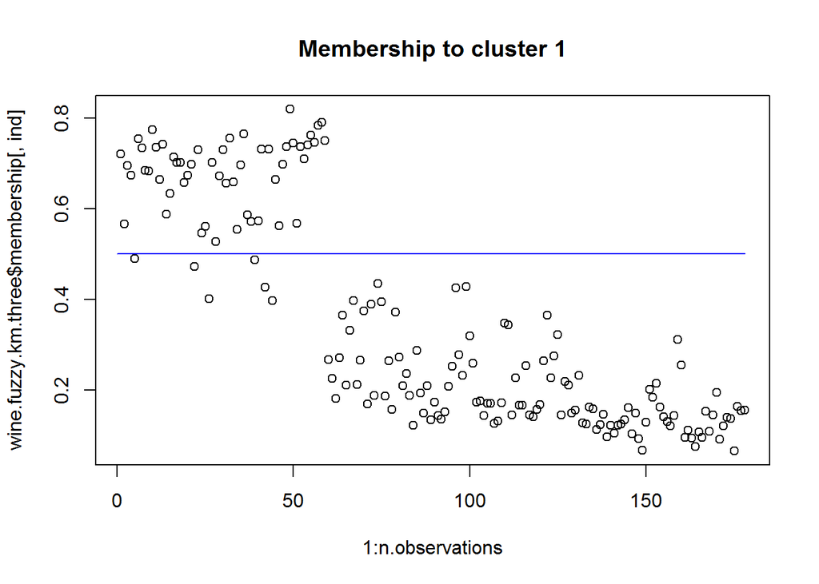

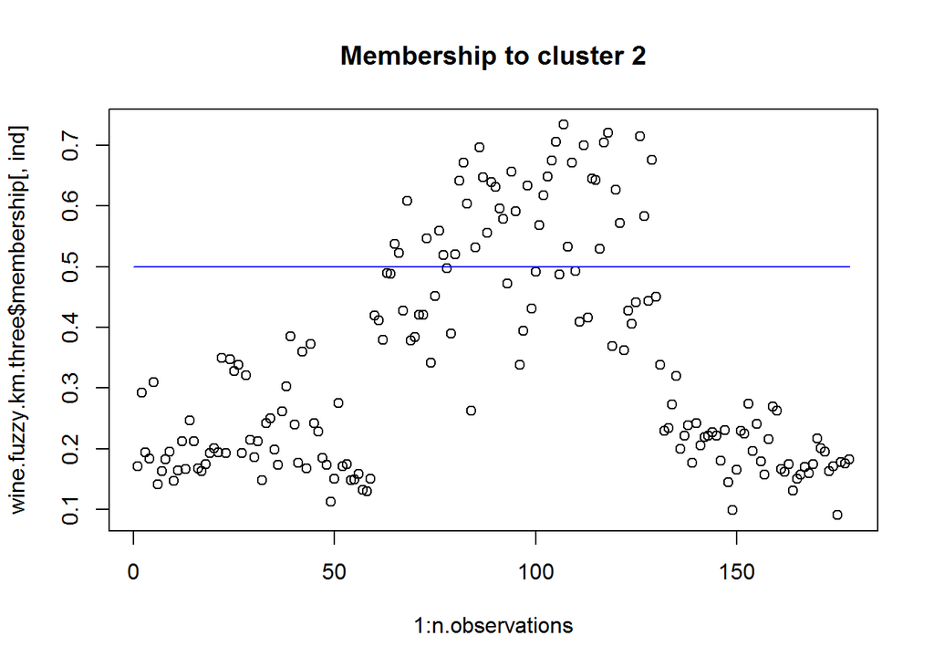

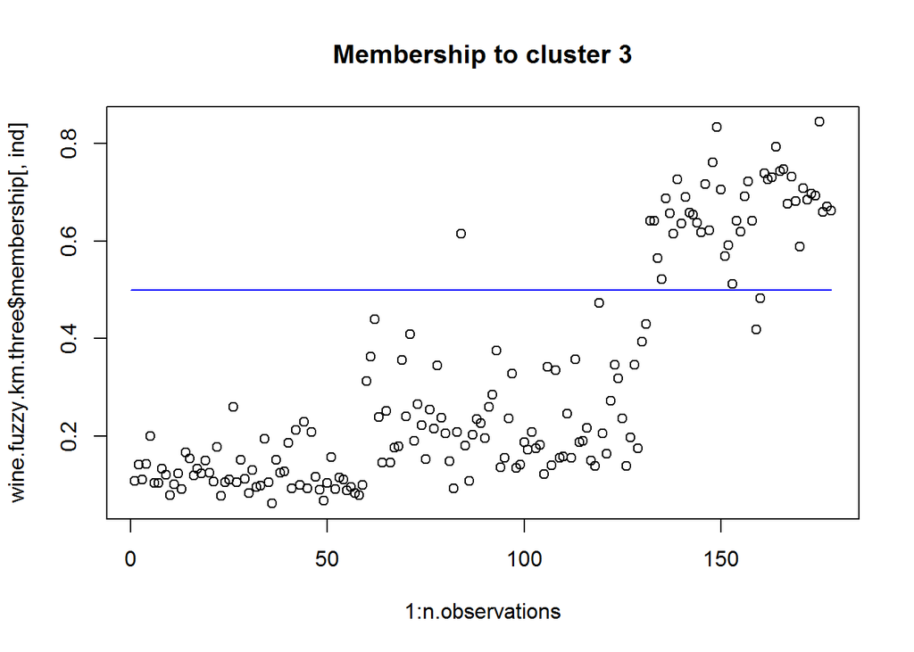

```r
n.observations <- nrow(wine)

for(ind in 1:3) {
  plot(1:n.observations, wine.fuzzy.km.three$membership[, ind], main = paste0("Membership to cluster ", ind))
  lines(0:n.observations,rep(0.5,n.observations+1),col = "blue")
}
```

Принадлежность к кластеру 2 в проекции на первые два главные направления.

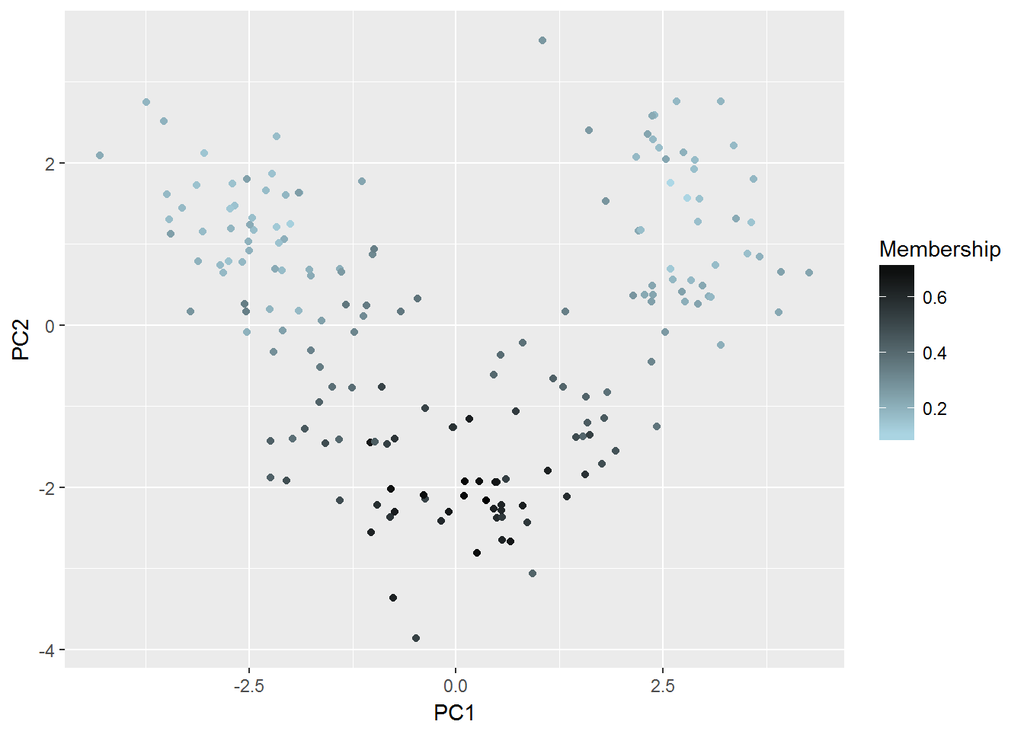

```r
ggplot(cbind(wine.pca.data, wine.fuzzy.km.three$membership), aes(PC1, PC2, colour = wine.fuzzy.km.three$membership[, 2])) + geom_point() + scale_colour_gradient(low="lightblue", high = "black", name = "Membership")
```

## Иерархическая кластеризация

Используем функцию **hclust**.

- d - матрица расстояний (результат функции dist)
- method - межкластерное расстояние

Будем использовать евклидову метрику.

### Complete linkage

Расстояние дальнего соседа $R^l(U, V) = max_{u \in U, v \in V} \rho(u,v)$.

```r
wine.dist <- dist(wine.pca.data, method = "euclidian")
wine.h.fit <- hclust(wine.dist, method = "complete")
```

Дендограмма с разделением на 3 кластера.

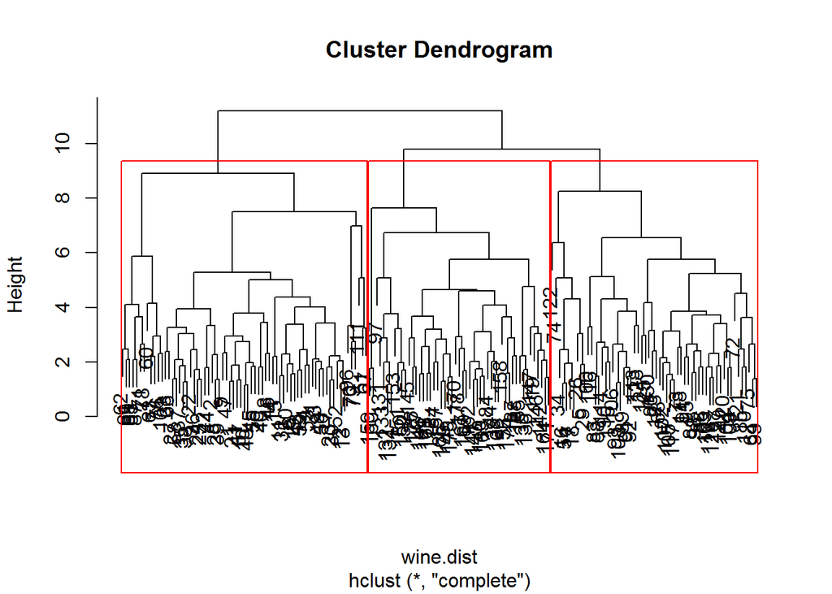

```r
plot(wine.h.fit)

rect.hclust(wine.h.fit, k=3, border="red")
```

```r
wine.groups <- cutree(wine.h.fit, k = 3)
```

Таблица правильных и ошибочных предсказаний в сравнении со значениями признака Type.

```r
tb <- table(wine$Type, wine.groups)
print(tb)
```

```
##    wine.groups
##      1  2  3
##   1 51  8  0
##   2 18 50  3
##   3  0  0 48
```

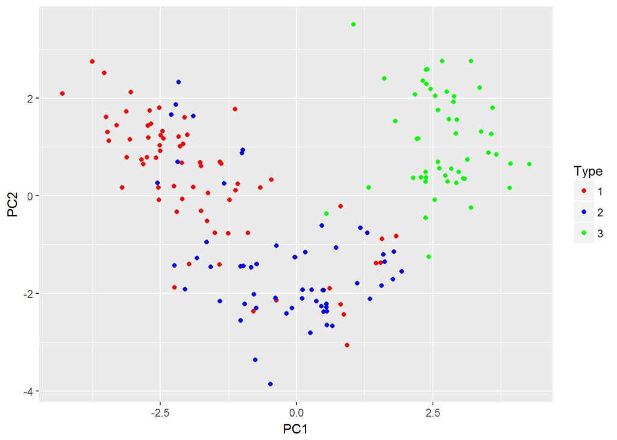

```r
ggplot(cbind(wine.pca.data, wine.groups), aes(PC1, PC2, colour = as.factor(wine.groups))) + geom_point() + scale_color_manual(values = c("red", "blue", "green"), name = "Type")
```

```r
mean(diag(prop.table(tb, 1)))
```

```
## [1] 0.8562107
```

### Ward distance

Расстояние Уорда $R^w (U,V) = \frac{|U||V|}{|U| + |V|}R^c(U,V)$. При исполльзовании расстояния Уорда минимизируются внутригрупповые дисперсии. Хорошо использовать для объединения близко расположенных кластеров.

```r
wine.dist <- dist(wine.pca.data, method = "euclidian")
wine.h.fit <- hclust(wine.dist, method = "ward.D")
```

Дендограмма с разделением на 3 кластера.

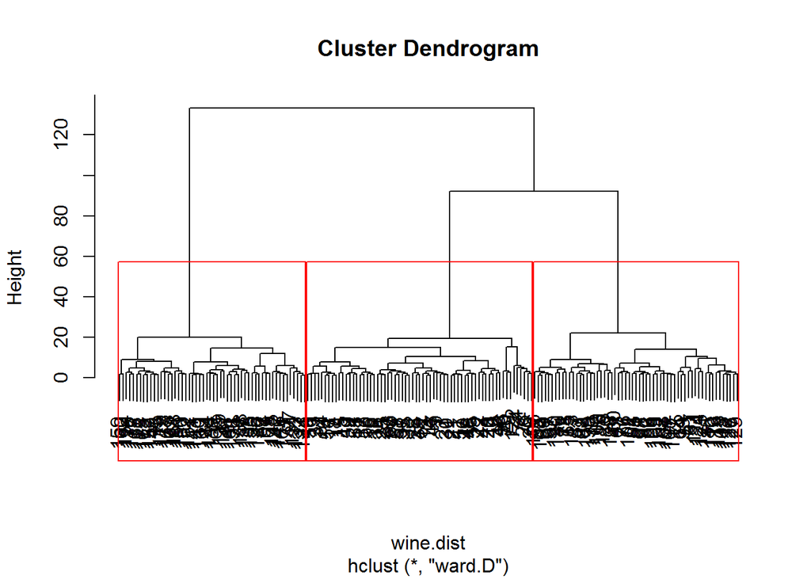

```r
plot(wine.h.fit)

rect.hclust(wine.h.fit, k=3, border="red")
```

```r
wine.groups <- cutree(wine.h.fit, k = 3)
```

Таблица правильных и ошибочных предсказаний в сравнении со значениями признака Type. При использовании расстояния Уорда количество ошибочных предсказаний сократилось.

```r
tb <- table(wine$Type, wine.groups)
print(tb)
```

```
##    wine.groups
##      1  2  3
##   1 58  1  0
##   2  7 58  6
##   3  0  0 48
```

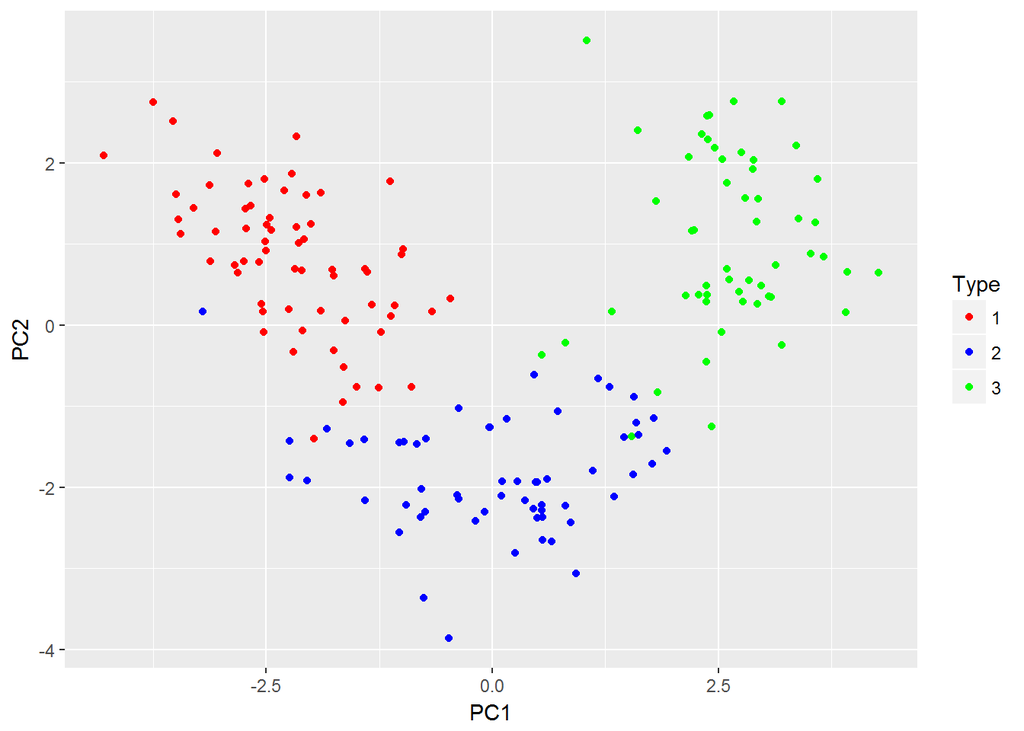

```r
ggplot(cbind(wine.pca.data, wine.groups), aes(PC1, PC2, colour = as.factor(wine.groups))) + geom_point() + scale_color_manual(values = c("red", "blue", "green"), name = "Type")
```

```r
mean(diag(prop.table(tb, 1)))
```

```
## [1] 0.9333174
```

## Самоорганизующиеся карты Кохонена

Пакет **kohonen** функция **som**.

- grid: прямоугольная или шестиугольная сетка узлов, например, результат функции somgrid
- rlen: количество раз, когда полный набор данных будет представлен в сети
- alpha: скорость обучения, по умолчанию снижается линейно с 0.05 до 0.01

Идея cамоорганизующихся карт Кохонена заключается в том, чтобы спроецировать все объекты выборки на плоскую карту: на множество узлов прямоугольной сетки заранее заданного размера (в нашем случае - это сетка grid).

Каждый объект проецируется в какой-то узел сетки.Чтобы карта отражала кластерную структуру выборки, близкие объекты должны попадать в близкие узлы сетки.

Посмотрим на карту Кохонена для двух явно выраженных кластеров. Смоделируем данные.

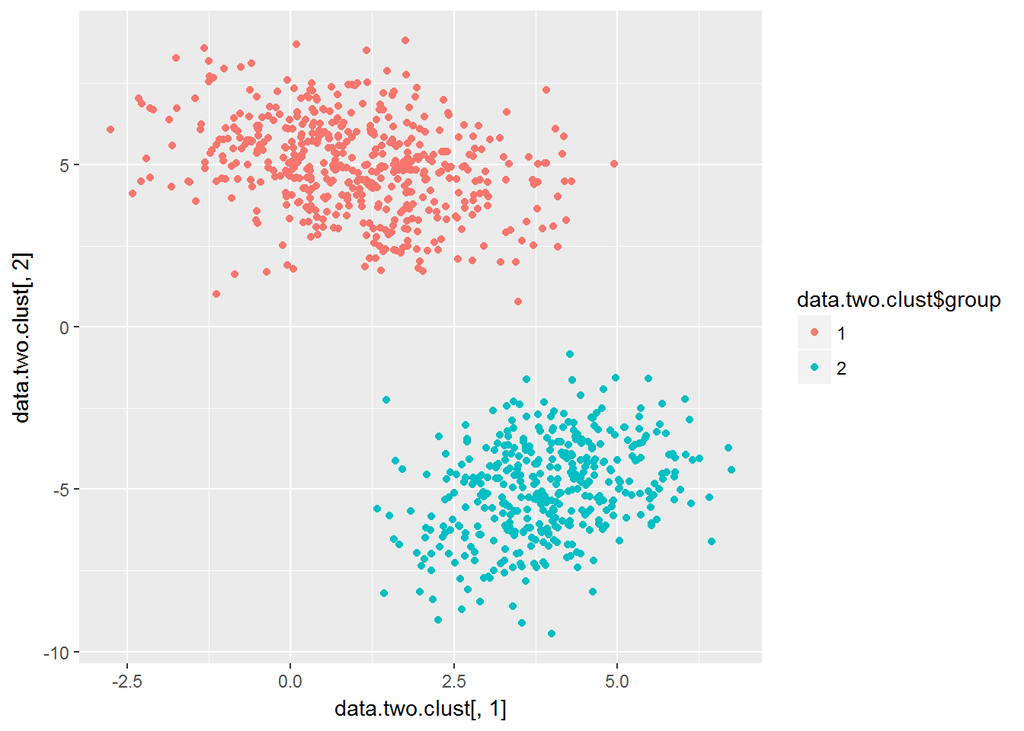

```r
library(MASS)
set.seed(10)
n1 <- 500
n2 <- 400
data.norm1 <- MASS::mvrnorm(n = n1, mu = c(1,5), Sigma = matrix(c(2,-0.5,1,2), nrow = 2))
data.norm2 <- MASS::mvrnorm(n = n2, mu = c(4,-5), Sigma = matrix(c(1,0.5,-0.5,2), nrow = 2))

data.two.clust <- as.data.frame(rbind(data.norm1, data.norm2))
data.two.clust$group <- as.factor(c(rep(1, n1), rep(2, n2)))

ggplot(data.two.clust, aes(data.two.clust[,1], data.two.clust[,2], colour = data.two.clust$group)) + geom_point()
```

```r
som.grid <- kohonen::somgrid(xdim = 6, ydim=6, topo="hexagonal")

som.model <- kohonen::som(scale(data.two.clust[, -3]),
 grid=som.grid,
 rlen=500,
 alpha=c(0.05,0.01),
 keep.data = TRUE)
```

На графике “Counts plot” для каждого узла отображено количество индивидов, попавших в этот узел. В левой и правой части картинки можно наблюдать группы узлов, окрашенных в красный цвет (в эти узлы попало около 40 индивидов). Между этими группами преобладают узлы с синим и зеленым цветом, то есть узлы, в которые попало не так много индивидов.

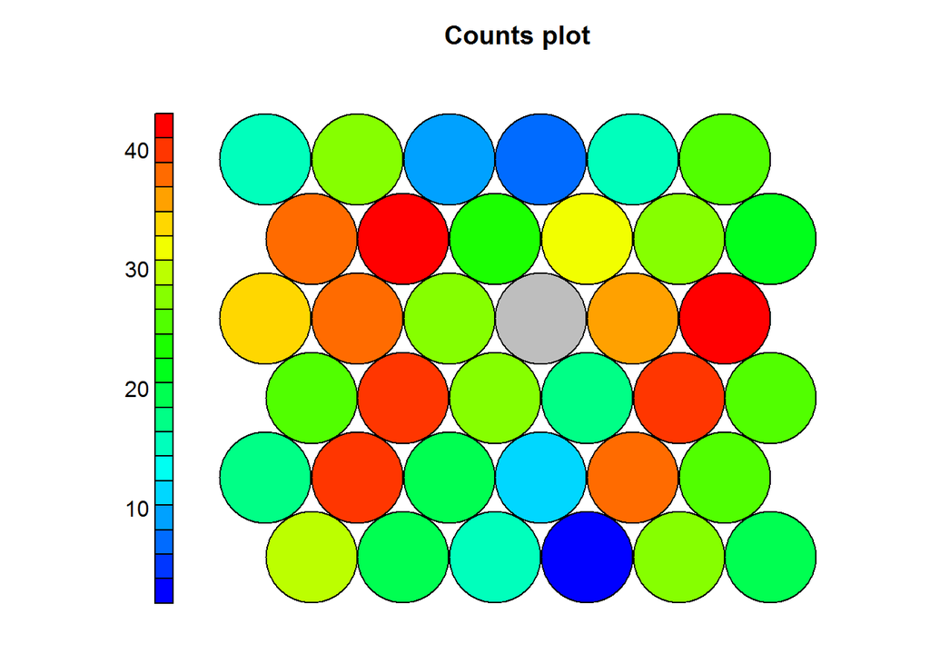

```r
colors <- function(n, alpha = 1) {
    rev(heat.colors(n, alpha))
}

coolBlueHotRed <- function(n, alpha = 1) {
    rainbow(n, end = 4/6, alpha = alpha)[n:1]
}
plot(som.model, type = "counts", palette.name = coolBlueHotRed, heatkey = TRUE)
```

Распределение индивидов по узлам без цветовой дифференциации.

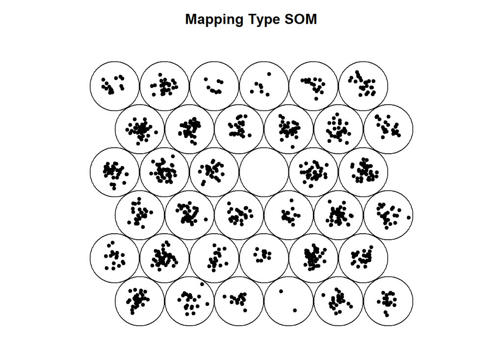

```r
plot(som.model, type = "mapping", pchs = 20, main = "Mapping Type SOM")
```

Расстояние между каждым узлом и его соседями (двухцветная полутоновая карта). Более светлый цвет отображает группы узлов, которые значительно отличаются друг от друга. По середине карты располгается группа узлов более светлого оттенка, тогда как в левой и правой части находятся более яркие узлы. По этой карте можно выделить два кластера в исходных данных.

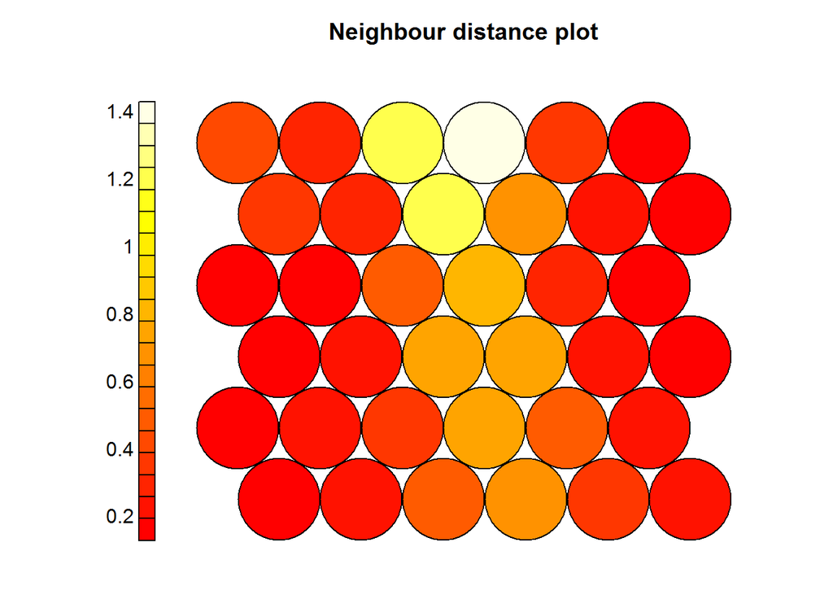

```r
plot(som.model, type = "dist.neighbours")
```

Распределение по решетке соотношение долей участия отдельных исходных переменных. На этой карте отображаются итоговые значения $\omega_{mh}$. Каждый цвет соответствует $j$-ой компоненте вектора $\omega_{mh}$.

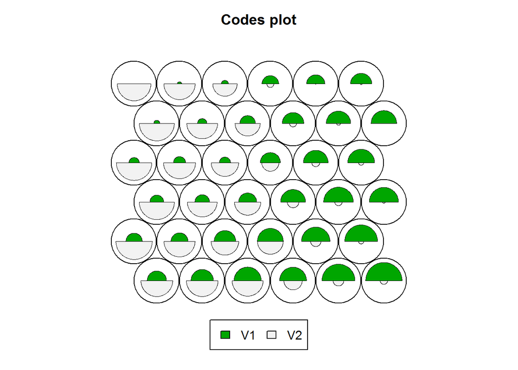

```r
plot(som.model, type = "codes")
```

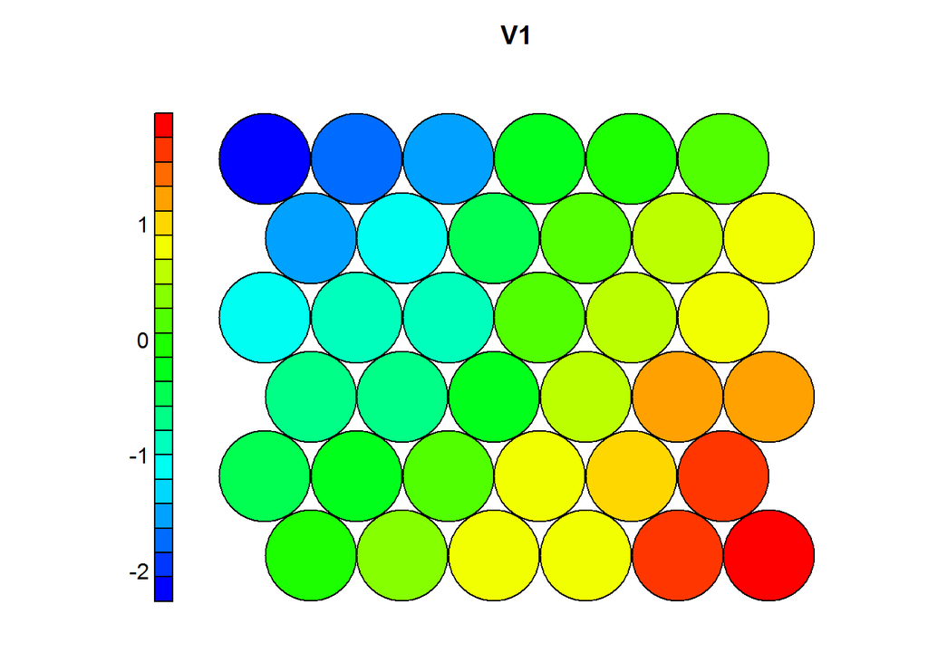

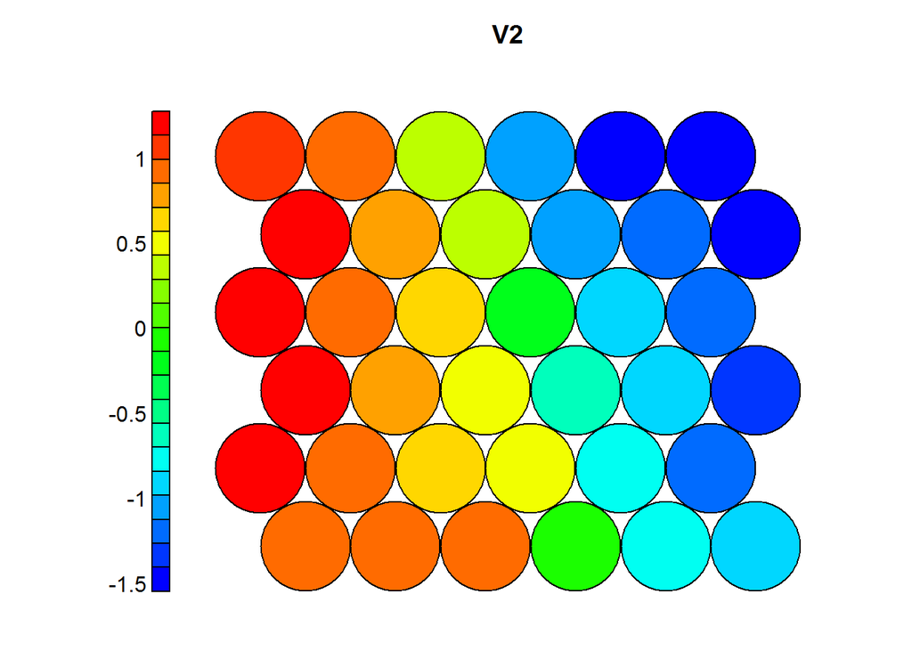

```r
for (i in 1:2) {
  plot(som.model, type = "property",
       property = som.model$codes[[1]][,i],
       main = colnames(som.model$codes[[1]])[i],
       palette.name = coolBlueHotRed)
}
```

Построим карту Кохонена для данных **wine**.

```r
set.seed(20)
som.grid <- kohonen::somgrid(xdim = 6, ydim=6, topo="hexagonal")

som.model <- kohonen::som(scale(wine.pca.data),
 grid=som.grid,
 rlen=500,
 alpha=c(0.05,0.01),
 keep.data = TRUE)
```

На графике “Counts plot” для каждого узла отображено количество индивидов, попавших в этот узел. На карте можно заметить два места скопления точек (красные узлы), между которыми находятся узлы с небольшим количеством точек. Также в правой части карты находится узел желтоватого цвета, который имеет большее скопление точек, чем другие окружающие его узлы.

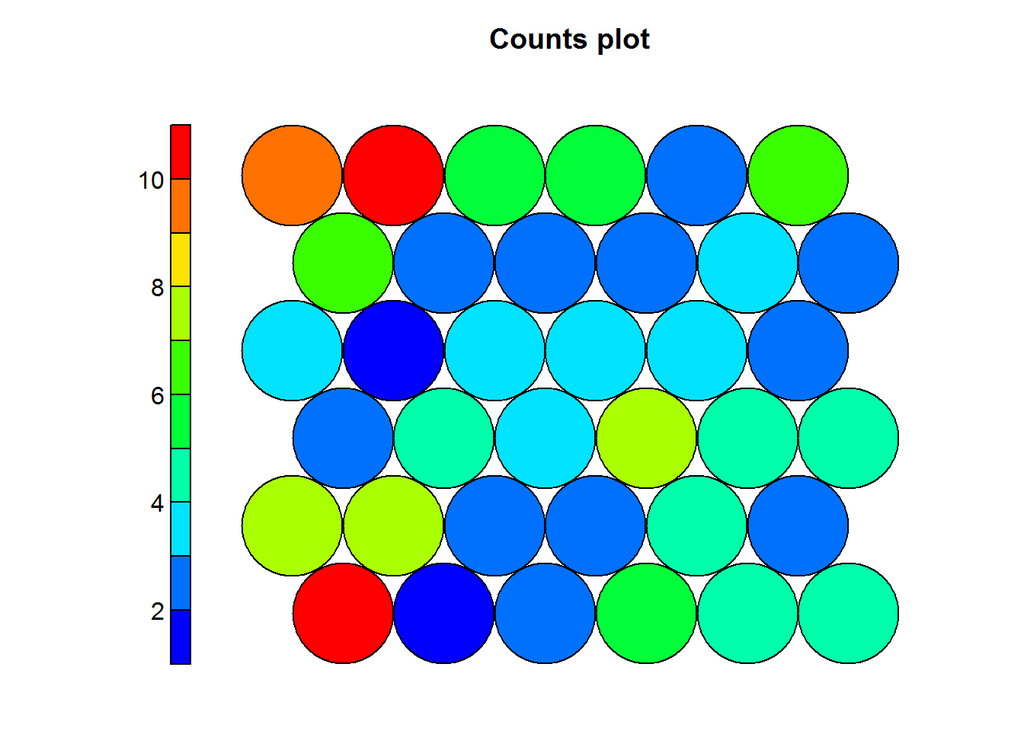

```r
colors <- function(n, alpha = 1) {
    rev(heat.colors(n, alpha))
}

coolBlueHotRed <- function(n, alpha = 1) {
    rainbow(n, end = 4/6, alpha = alpha)[n:1]
}
plot(som.model, type = "counts", palette.name = coolBlueHotRed, heatkey = TRUE)
```

Распределение индивидов по узлам.

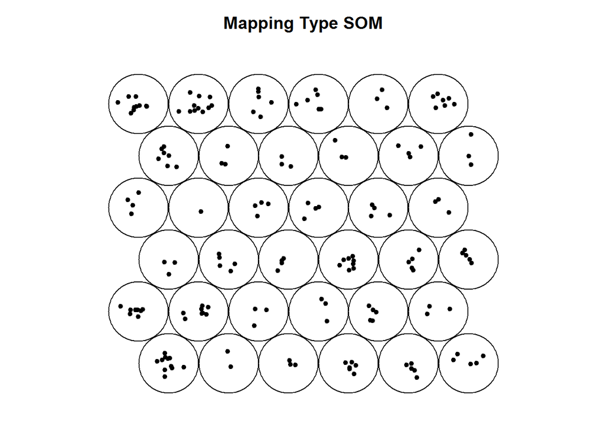

```r
plot(som.model, type = "mapping", pchs = 20, main = "Mapping Type SOM")
```

Расстояние между каждым узлом и его соседями. В левом нижнем углу карты выделяется группа узлов, которая окружена узлами более светлого цвета, эту группу можно выделить в отдельный кластер. Граница между скоплениями в левом верхнем и правом нижнем углах карты размыта.

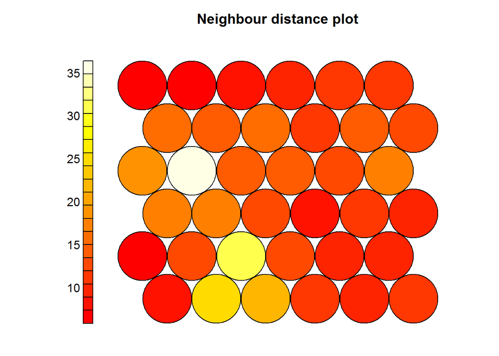

```r
plot(som.model, type = "dist.neighbours")
```

Распределение по решетке соотношение долей участия отдельных исходных переменных. Так как у нас участвует много признаков, то сложно интерпретировать такую карту.

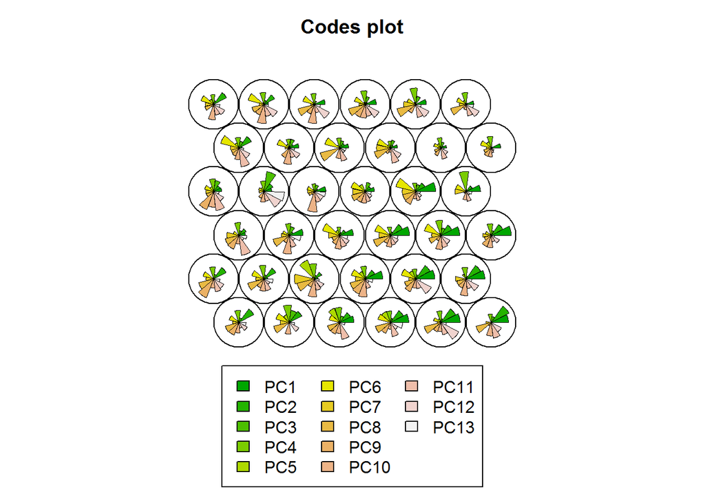

```r
plot(som.model, type = "codes")
```

Нарисуем для первых четырех глвных компонент долю участия. Для кластера, находящегося в нижнем правом углу карту, соответсвуют повышенные значения первой главной компоненты.

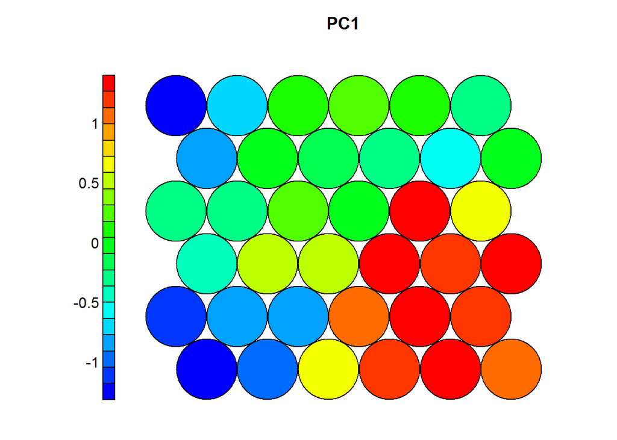

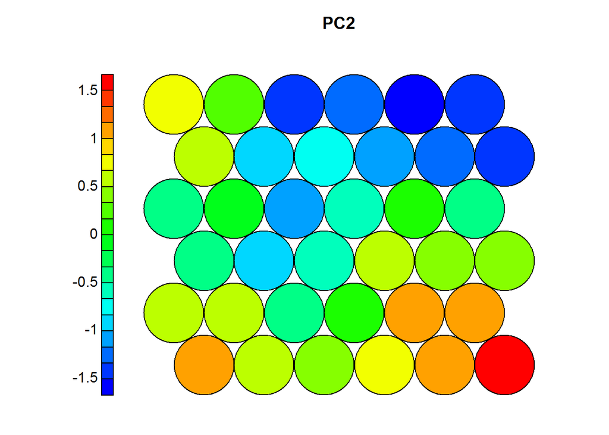

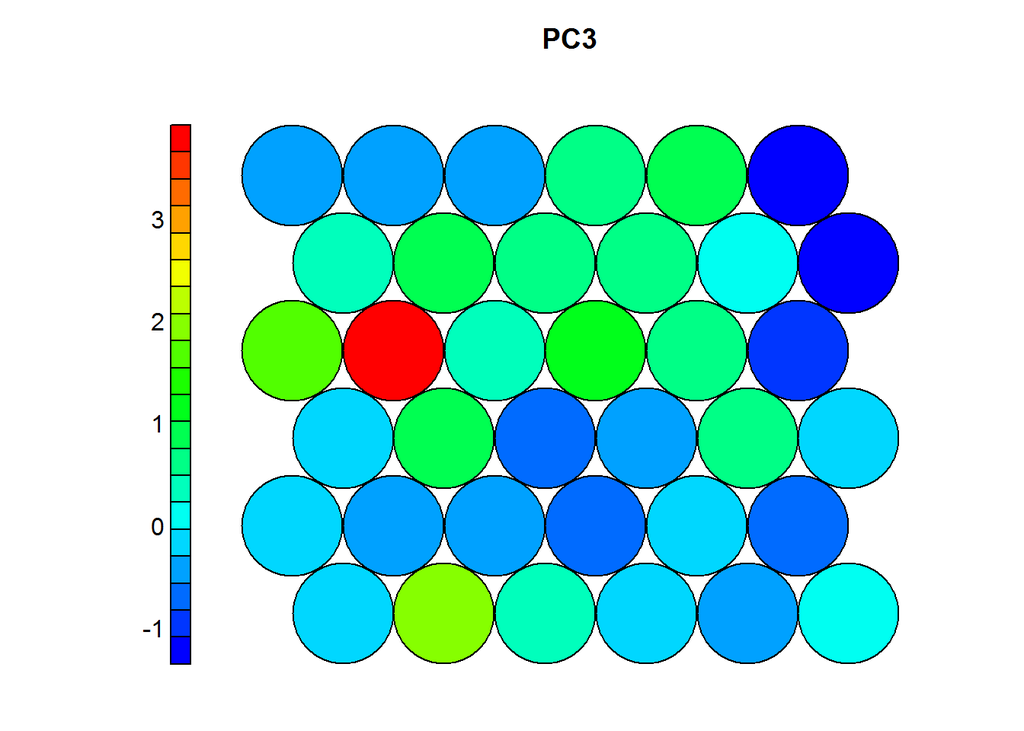

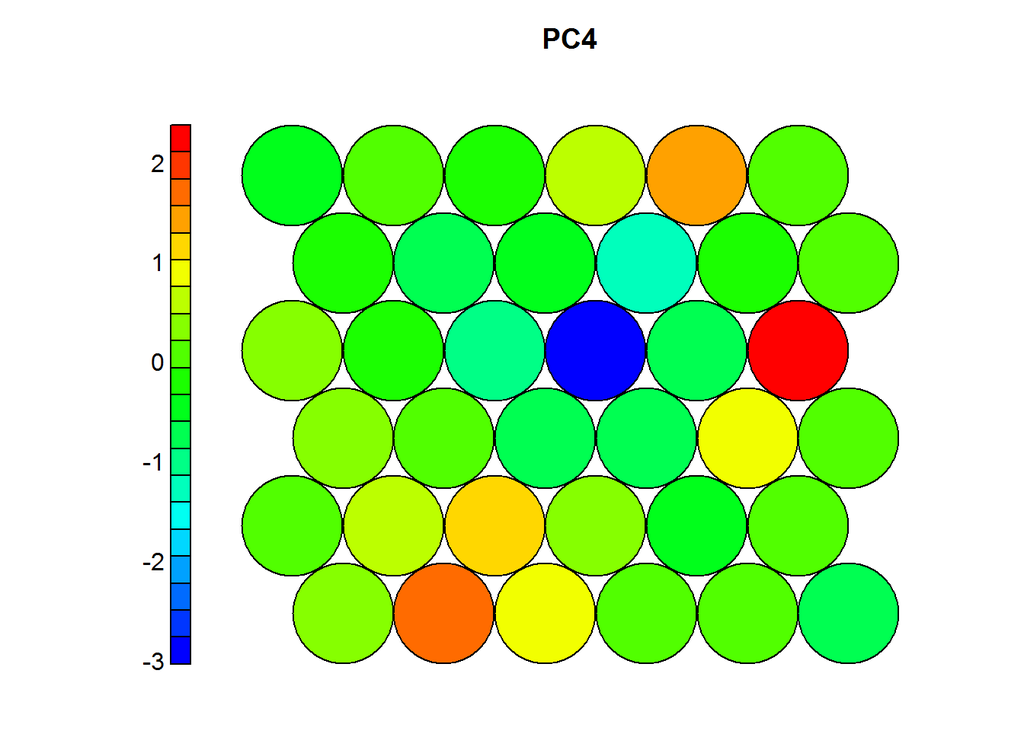

```r
for (i in 1:4) {
  plot(som.model, type = "property",
       property = som.model$codes[[1]][,i],
       main = colnames(som.model$codes[[1]])[i],
       palette.name = coolBlueHotRed)
}
```